# Exercise: Did the Coupon Work? — Solutions

Davide Proserpio

2026-11-10

This is the instructor solution to the causality exercise. The data are fixed (no seed, no split), so your numbers should match the ones below to the third decimal. The true effect of the coupon is **2.0** in every scenario.

# Task 1: Load and explore

```r
# Read the data. fread() is data.table's csv reader; it returns a data.table
df <- fread("causality_data.csv")

# First rows: one row = one customer. intent_to_buy is empty (NA) outside
# scenario 3
head(df)
```

```
##    scenario  sales coupon price_sensitivity mobile intent_to_buy
##       <int>  <num>  <int>             <num>  <int>         <int>
## 1:        1 11.358      0             0.788      0            NA
## 2:        1 17.087      0             0.769      1            NA
## 3:        1 18.182      1             0.332      1            NA
## 4:        1 11.214      0            -1.008      1            NA
## 5:        1 13.878      0            -0.119      1            NA
## 6:        1 10.673      0            -0.280      0            NA
```

```r
# One data set per scenario. In data.table, df[condition] keeps the rows
# where the condition is TRUE
s1 <- df[scenario == 1]   # the experiment: coupon assigned at random
s2 <- df[scenario == 2]   # targeted on variables we see (price_sensitivity, mobile)
s3 <- df[scenario == 3]   # targeted on those AND on something we do not see

# Share of customers who received the coupon, by scenario.
# coupon is 0/1, so its mean is the share of 1s. .N counts the rows in
# each group
df[, .(customers = .N, share_coupon = round(mean(coupon), 3)), by = scenario]
```

```
##    scenario customers share_coupon
##       <int>     <int>        <num>
## 1:        1      5000        0.492
## 2:        2      5000        0.508
## 3:        3      5000        0.594
```

**Why is “average sales of coupon customers minus average sales of no-coupon customers” not automatically the effect of the coupon?**

Because the two groups may have been different **before** the coupon arrived. The difference in average sales mixes two things: what the coupon did, and how the kind of customer who gets a coupon differs from the kind who does not. Only when the groups are comparable to begin with (as in an experiment) is the difference in means the effect of the coupon. The coupon share already hints at this: about half of the customers in scenarios 1 and 2, but **59%** in scenario 3, where marketing targeted harder.

# Task 2: Scenario 1, the experiment

```r
# Balance check: are the two groups alike BEFORE the coupon does anything?
# For each pre-treatment variable we compare its average in the no-coupon
# group (coupon = 0) with its average in the coupon group (coupon = 1).
#
# t.test(y ~ group, data) runs a two-sample t-test. It prints:
#   - the two group means, at the bottom ("mean in group 0", "mean in group 1")
#   - a p-value for the null hypothesis "the two means are equal"
# A p-value above 0.05 means the gap between the groups is the kind of gap
# chance produces: the groups are balanced on that variable
t.test(price_sensitivity ~ coupon, data = s1)
```

```
##
##  Welch Two Sample t-test
##
## data:  price_sensitivity by coupon
## t = 0.54945, df = 4995, p-value = 0.5827
## alternative hypothesis: true difference in means between group 0 and group 1 is not equal to 0
## 95 percent confidence interval:
##  -0.03961232  0.07046321
## sample estimates:
## mean in group 0 mean in group 1
##     0.007342520    -0.008082927
```

```r
# mobile is 0/1, so its mean is the share of mobile shoppers in each group
t.test(mobile ~ coupon, data = s1)
```

```
##
##  Welch Two Sample t-test
##
## data:  mobile by coupon
## t = -1.784, df = 4992.5, p-value = 0.07449
## alternative hypothesis: true difference in means between group 0 and group 1 is not equal to 0
## 95 percent confidence interval:
##  -0.052940071  0.002495157
## sample estimates:
## mean in group 0 mean in group 1
##       0.4755906       0.5008130
```

> **How to read the t-test output.** The two numbers under “sample estimates” are the group averages: group 0 is the no-coupon group, group 1 the coupon group. The p-value tests whether those two averages differ by more than chance. The confidence interval is for the difference **group 0 minus group 1** (R’s order, not ours), which is why we compute the coupon-minus-no-coupon gap ourselves below.

```r
# Estimate 1: the difference in mean sales, coupon minus no-coupon.
# The t-test prints the two means and the p-value, but not the gap itself,
# so we compute it: average sales of the coupon customers minus average
# sales of the no-coupon customers
t.test(sales ~ coupon, data = s1)
```

```
##
##  Welch Two Sample t-test
##
## data:  sales by coupon
## t = -19.372, df = 4994.5, p-value < 2.2e-16
## alternative hypothesis: true difference in means between group 0 and group 1 is not equal to 0
## 95 percent confidence interval:
##  -2.424652 -1.979007
## sample estimates:
## mean in group 0 mean in group 1
##        11.39301        13.59484
```

```r
s1[, mean(sales[coupon == 1]) - mean(sales[coupon == 0])]
```

```
## [1] 2.20183
```

```r
# Estimate 2: a regression of sales on the coupon dummy.
# With a single 0/1 regressor, the coupon coefficient IS the difference in
# means above. The regression adds a standard error and lets us add controls
ols1  <- lm(sales ~ coupon, data = s1)

# Estimate 3: the same regression with the two pre-treatment variables as
# controls. The coupon coefficient now compares customers with the same
# price sensitivity and the same device
ols1c <- lm(sales ~ coupon + price_sensitivity + mobile, data = s1)

# The two regressions side by side, one column each
stargazer(ols1, ols1c, type = "text", no.space = TRUE,
          title = "Scenario 1: random coupon",
          dep.var.labels = "Sales", keep.stat = c("n", "rsq"),
          covariate.labels = c("Coupon", "Price sensitivity", "Mobile"))
```

```
##
## Scenario 1: random coupon
## ==============================================
##                       Dependent variable:
##                   ----------------------------
##                              Sales
##                        (1)            (2)
## ----------------------------------------------
## Coupon               2.202***      2.144***
##                      (0.114)        (0.099)
## Price sensitivity                  1.207***
##                                     (0.050)
## Mobile                             3.044***
##                                     (0.099)
## Constant            11.393***      9.937***
##                      (0.080)        (0.084)
## ----------------------------------------------
## Observations          5,000          5,000
## R2                    0.070          0.289
## ==============================================
## Note:              *p<0.1; **p<0.05; ***p<0.01
```

> **How to read the regression table.** Each column is one regression. Each cell shows the coefficient with its standard error in parentheses underneath; the stars mark p < 0.10 (*), p < 0.05 (**), and p < 0.01 (***). The number we care about is the **Coupon** row: the estimated effect of receiving the coupon on sales, holding the other variables in that column fixed. An estimate is “close to 2.0” if 2.0 is within about two standard errors of it.

**Are the two groups comparable before the coupon does anything? What makes them comparable?**

Yes. Average price sensitivity is **0.007** in the no-coupon group and **−0.008** in the coupon group (p = 0.58); the mobile share is **47.6%** against **50.1%** (p = 0.07). Neither gap is bigger than chance produces. They are comparable because the coupon was assigned **at random**: a coin flip cannot know anything about the customer, so it cannot favor one kind of customer over another, on the variables we see or on the ones we do not.

**How close do the estimates get to 2.0?**

The difference in means and the regression without controls both give **2.202** (standard error 0.114); with controls, **2.144** (standard error 0.099). All three are within two standard errors of the true 2.0. The controls do not move the estimate because, under random assignment, there is no confounding to remove.

# Task 3: Scenario 2, the targeted coupon

```r
# Same balance check as in Task 2, on the scenario 2 rows.
# This time we expect gaps: marketing chose who gets the coupon
t.test(price_sensitivity ~ coupon, data = s2)
```

```
##
##  Welch Two Sample t-test
##
## data:  price_sensitivity by coupon
## t = -32.35, df = 4993.6, p-value < 2.2e-16
## alternative hypothesis: true difference in means between group 0 and group 1 is not equal to 0
## 95 percent confidence interval:
##  -0.8760079 -0.7759007
## sample estimates:
## mean in group 0 mean in group 1
##      -0.4195012       0.4064531
```

```r
t.test(mobile ~ coupon, data = s2)
```

```
##
##  Welch Two Sample t-test
##
## data:  mobile by coupon
## t = -6.561, df = 4994.7, p-value = 5.884e-11
## alternative hypothesis: true difference in means between group 0 and group 1 is not equal to 0
## 95 percent confidence interval:
##  -0.11999110 -0.06478119
## sample estimates:
## mean in group 0 mean in group 1
##       0.4411048       0.5334909
```

```r
# Same three estimates as in Task 2, on the scenario 2 rows

# Estimate 1: difference in mean sales, coupon minus no-coupon
t.test(sales ~ coupon, data = s2)
```

```
##
##  Welch Two Sample t-test
##
## data:  sales by coupon
## t = -29.245, df = 4987.1, p-value < 2.2e-16
## alternative hypothesis: true difference in means between group 0 and group 1 is not equal to 0
## 95 percent confidence interval:
##  -3.500327 -3.060521
## sample estimates:
## mean in group 0 mean in group 1
##        10.75517        14.03560
```

```r
s2[, mean(sales[coupon == 1]) - mean(sales[coupon == 0])]
```

```
## [1] 3.280424
```

```r
# Estimate 2: regression without controls (same number as Estimate 1)
ols2  <- lm(sales ~ coupon, data = s2)

# Estimate 3: regression with the two targeting variables as controls
ols2c <- lm(sales ~ coupon + price_sensitivity + mobile, data = s2)

stargazer(ols2, ols2c, type = "text", no.space = TRUE,
          title = "Scenario 2: targeted coupon",
          dep.var.labels = "Sales", keep.stat = c("n", "rsq"),
          covariate.labels = c("Coupon", "Price sensitivity", "Mobile"))
```

```
##
## Scenario 2: targeted coupon
## ==============================================
##                       Dependent variable:
##                   ----------------------------
##                              Sales
##                        (1)            (2)
## ----------------------------------------------
## Coupon               3.280***      1.974***
##                      (0.112)        (0.110)
## Price sensitivity                  1.245***
##                                     (0.055)
## Mobile                             3.014***
##                                     (0.100)
## Constant            10.755***      9.948***
##                      (0.080)        (0.086)
## ----------------------------------------------
## Observations          5,000          5,000
## R2                    0.146          0.333
## ==============================================
## Note:              *p<0.1; **p<0.05; ***p<0.01
```

**Which variable is most out of balance, and what does that say about how marketing targeted the coupon?**

**Price sensitivity**: the coupon group averages **0.41**, the no-coupon group **−0.42**, a gap of 0.8 standard deviations (p < 0.001). Mobile is also out of balance (**53.3%** vs. **44.1%**, p < 0.001), but by less. Marketing sent the coupon mostly to price-sensitive customers, and somewhat more to mobile shoppers.

**The naive comparison misses 2.0 badly while the regression with controls comes back to it. Why?**

The naive comparison gives **3.280**, well above 2.0. In these data, price-sensitive and mobile customers buy more (the controls have positive coefficients: about 1.2 per unit of price sensitivity and about 3.0 for mobile). Marketing sent the coupon to exactly those customers, so the coupon group would have had higher sales **even without the coupon**. The naive comparison credits that head start to the coupon.

With controls the estimate is **1.974** (standard error 0.110), on top of 2.0. Controlling works **in this scenario** because marketing targeted on `price_sensitivity` and `mobile` only, and both are in the file. Once we compare customers with the same price sensitivity and the same device, who gets the coupon is as good as random.

# Task 4: Scenario 3, the hidden targeting

```r
# Scenario 3 rows. Same two regressions as before: without controls, and
# with price_sensitivity and mobile. intent_to_buy is still ignored, as the
# task says
ols3  <- lm(sales ~ coupon, data = s3)
ols3c <- lm(sales ~ coupon + price_sensitivity + mobile, data = s3)

stargazer(ols3, ols3c, type = "text", no.space = TRUE,
          title = "Scenario 3: hidden targeting, intent_to_buy ignored",
          dep.var.labels = "Sales", keep.stat = c("n", "rsq"),
          covariate.labels = c("Coupon", "Price sensitivity", "Mobile"))
```

```
##
## Scenario 3: hidden targeting, intentignored
## ==============================================
##                       Dependent variable:
##                   ----------------------------
##                              Sales
##                        (1)            (2)
## ----------------------------------------------
## Coupon               3.628***      2.455***
##                      (0.120)        (0.118)
## Price sensitivity                  1.140***
##                                     (0.058)
## Mobile                             3.001***
##                                     (0.107)
## Constant            12.021***      11.254***
##                      (0.092)        (0.099)
## ----------------------------------------------
## Observations          5,000          5,000
## R2                    0.155          0.313
## ==============================================
## Note:              *p<0.1; **p<0.05; ***p<0.01
```

**Neither estimate lands on 2.0, not even with controls. What went wrong?**

Without controls, **3.628**; with the same controls that worked in scenario 2, **2.455** (standard error 0.118), still four standard errors above the truth. The controls remove the part of the targeting that ran through price sensitivity and mobile, but marketing also used something **that is not in these two columns**. Customers with that something got the coupon more often **and** buy more, so the coupon still gets credit for sales it did not produce. No amount of data on the same two variables can fix this.

**What two things must a missing variable do, at the same time, to create this bias?**

1. It must affect **who gets the coupon** (it is correlated with the treatment).
2. It must affect **sales** on its own (it is correlated with the outcome).

A variable that does only one of the two is harmless: if it drives sales but not the coupon, it just adds noise; if it drives the coupon but not sales, the coupon group is different in a way that does not matter for the outcome.

# Task 5: Scenario 3, adding the missing variable

```r
# intent_to_buy is 0/1: 1 = the customer already wanted to buy.
# Its mean within each group is the share of high-intent customers.
# If marketing used it to target, the share should be higher in the
# coupon group
s3[, .(share_high_intent = round(mean(intent_to_buy), 3)), by = coupon]
```

```
##    coupon share_high_intent
##     <int>             <num>
## 1:      1             0.570
## 2:      0             0.392
```

```r
# The Task 4 regression with intent_to_buy added as a third control
ols3i <- lm(sales ~ coupon + price_sensitivity + mobile + intent_to_buy, data = s3)

# Left column: Task 4 (intent_to_buy ignored). Right column: with it
stargazer(ols3c, ols3i, type = "text", no.space = TRUE,
          title = "Scenario 3: adding the hidden variable",
          dep.var.labels = "Sales", keep.stat = c("n", "rsq"),
          covariate.labels = c("Coupon", "Price sensitivity", "Mobile", "Intent to buy"))
```

```
##
## Scenario 3: adding the hidden variable
## ==============================================
##                       Dependent variable:
##                   ----------------------------
##                              Sales
##                        (1)            (2)
## ----------------------------------------------
## Coupon               2.455***      1.772***
##                      (0.118)        (0.111)
## Price sensitivity    1.140***      1.307***
##                      (0.058)        (0.054)
## Mobile               3.001***      3.042***
##                      (0.107)        (0.098)
## Intent to buy                      3.068***
##                                     (0.099)
## Constant            11.254***      10.113***
##                      (0.099)        (0.098)
## ----------------------------------------------
## Observations          5,000          5,000
## R2                    0.313          0.423
## ==============================================
## Note:              *p<0.1; **p<0.05; ***p<0.01
```

**What happens to the coupon estimate?**

It drops from **2.455** to **1.772** (standard error 0.111), within about two standard errors of 2.0. The bias is gone; what is left is sampling noise. The table shows why it mattered: high-intent customers are **57%** of the coupon group but **39%** of the no-coupon group, and intent is worth about **3.1** in sales on its own. That is the head start the coupon had been taking credit for.

**What does this say about “just add more controls” as a strategy?**

It only works if you happen to have the variable that drove the targeting. Intent to buy is exactly the kind of thing a marketing team acts on and a data file never records (it lives in a model score, a sales rep’s judgment, or the customer’s head). You cannot test whether you have all the confounders; the data look the same in scenario 2 and scenario 3, and only one of them gives the right answer. The credibility of a controlled comparison rests on an **argument** about how the treatment was assigned, not on the number of controls.

# Task 6: Matching

```r
# Back to scenario 2. matchit() does two things in one call:
#
#   1. It estimates the propensity score: a logit regression of coupon on
#      price_sensitivity and mobile (distance = "logit"). Each customer gets
#      a predicted probability of receiving the coupon.
#
#   2. It pairs each coupon customer with the no-coupon customer whose
#      propensity score is closest (method = "nearest"), but only if the two
#      scores are within the caliper: 0.01 standard deviations of the score.
#      A coupon customer with no control that close stays unmatched.
#
# The formula reads "coupon explained by price_sensitivity and mobile":
# the treatment on the left, the variables marketing targeted on the right
m_out <- matchit(coupon ~ price_sensitivity + mobile, data = s2,
                 method = "nearest", distance = "logit", caliper = 0.01)

# Printing the object summarizes what was done
m_out
```

```
## A `matchit` object
##  - method: 1:1 nearest neighbor matching without replacement
##  - distance: Propensity score [caliper]
##
##              - estimated with logistic regression
##  - caliper: <distance> (0.002)
##  - number of obs.: 5000 (original), 3112 (matched)
##  - target estimand: ATT
##  - covariates: price_sensitivity, mobile
```

```r
# summary() of the matchit object holds the balance statistics
sm <- summary(m_out)

# Sample sizes. "All" = the full scenario 2 data (before matching),
# "Matched" = customers who found a partner, "Unmatched" = set aside.
# Columns: Control = no-coupon customers, Treated = coupon customers
sm$nn
```

```
##               Control Treated
## All (ESS)        2462    2538
## All              2462    2538
## Matched (ESS)    1556    1556
## Matched          1556    1556
## Unmatched         906     982
## Discarded           0       0
```

```r
# Balance before and after matching, from two tables inside the summary:
#   sm$sum.all      balance in the full data (before matching)
#   sm$sum.matched  balance in the matched customers only (after matching)
# We keep one column from each: "Std. Mean Diff.", the standardized mean
# difference. It is the gap between the two group means divided by the
# standard deviation, so that variables on different scales can be
# compared. Rule of thumb: below 0.1 in absolute value counts as balanced.
# The row called "distance" is MatchIt's name for the propensity score
# itself; we relabel it
balance <- data.table(
  variable = sub("^distance$", "propensity score", rownames(sm$sum.all)),
  smd_before = round(sm$sum.all[, "Std. Mean Diff."], 3),
  smd_after  = round(sm$sum.matched[, "Std. Mean Diff."], 3))
balance
```

```
##             variable smd_before smd_after
##               <char>      <num>     <num>
## 1:  propensity score      0.964     0.005
## 2: price_sensitivity      0.915     0.014
## 3:            mobile      0.185    -0.041
```

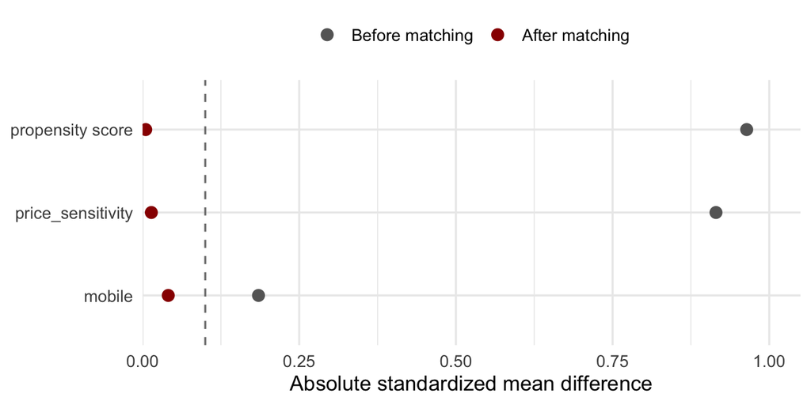

```r
# The same table as a picture (a "love plot"): one row per variable, a
# grey dot for the gap before matching and a red dot for the gap after.
# The dashed line is the 0.1 cutoff for "balanced"

# Reshape the table from wide (two columns of gaps) to long (one row per
# variable and sample), which is what ggplot wants
long <- melt(balance, id.vars = "variable",
             variable.name = "sample", value.name = "smd")

# Readable labels for the legend, and variables listed in the table's order
long[, sample := factor(sample, levels = c("smd_before", "smd_after"),
                        labels = c("Before matching", "After matching"))]
long[, variable := factor(variable, levels = rev(balance$variable))]

# The plot: absolute gap on the x-axis (we care about the size, not the
# sign), one variable per row, color = before/after
ggplot(long, aes(x = abs(smd), y = variable, color = sample)) +
  geom_vline(xintercept = 0.1, linetype = "dashed", color = "grey50") +
  geom_point(size = 3) +
  scale_color_manual(values = c("grey40", "#990000")) +
  scale_x_continuous(limits = c(0, 1), expand = expansion(mult = c(0, 0.05))) +
  labs(x = "Absolute standardized mean difference", y = NULL, color = NULL) +
  theme_minimal(base_size = 13) +
  theme(legend.position = "top")
```

**Did matching make the groups comparable?**

Yes, for the coupon customers who found a match. Before matching, the standardized difference in price sensitivity between the groups is **0.92** (and 0.19 for mobile); after matching it is **0.01** (and −0.04). Anything below 0.1 counts as balanced. The price was sample size: there are **2,538** coupon customers and only 2,462 controls, and with the 0.01 caliper only **1,556** coupon customers get a look-alike. The rest, mostly the most price-sensitive ones, have no close control and are set aside.

# Task 7: The effect on the matched sample

```r
# match.data() returns the matched customers only (the 1,556 pairs, so
# 3,112 rows), with two new columns:
#   weights   the matching weight (1 for every matched customer here)
#   subclass  which pair the customer belongs to
md <- match.data(m_out)

# The effect on the matched sample: a regression of sales on coupon, using
# the matching weights. With one-to-one matching every weight is 1, so this
# is simply the difference in mean sales between the matched coupon
# customers and their look-alikes. Writing weights = weights is the general
# recipe: it also works for matching schemes where the weights differ
att <- lm(sales ~ coupon, data = md, weights = weights)

# Left column: the naive regression on all of scenario 2 (from Task 3).
# Right column: the same regression on the matched sample
stargazer(ols2, att, type = "text", no.space = TRUE,
          title = "Scenario 2: naive vs. matched",
          dep.var.labels = "Sales", keep.stat = c("n", "rsq"),
          column.labels = c("Naive, all customers", "Matched sample"),
          covariate.labels = "Coupon")
```

```
##
## Scenario 2: naive vs. matched
## ================================================
##                      Dependent variable:
##              -----------------------------------
##                             Sales
##              Naive, all customers Matched sample
##                      (1)               (2)
## ------------------------------------------------
## Coupon             3.280***          1.841***
##                    (0.112)           (0.139)
## Constant          10.755***         11.471***
##                    (0.080)           (0.098)
## ------------------------------------------------
## Observations        5,000             3,112
## R2                  0.146             0.053
## ================================================
## Note:                *p<0.1; **p<0.05; ***p<0.01
```

**How close is the matched estimate to 2.0, compared with the naive comparison?**

The matched estimate is **1.841** (standard error 0.139), within about one standard error of 2.0; the naive comparison was **3.280**. Matching recovers the truth the same way the regression with controls did, by comparing coupon customers with no-coupon customers who look the same on price sensitivity and device, but it does it by construction rather than by a formula. It also answers a slightly different question: the effect **on the customers who got the coupon** (the ATT), not on everyone.

**Would the same matching fix scenario 3?**

No. Matching on `price_sensitivity` and `mobile` makes the groups alike on those two variables and nothing else. The groups would still differ on intent to buy, and the matched estimate would be biased just like the regression with controls was. Matching and regression rest on the **same assumption**: that everything driving the targeting is in the data. Matching is not a cure for a hidden confounder.